K Andrijauskaite Homework 3

```r
setwd("C:/Users/Kristina/Documents/2017-Spring-TSCI-5050")
```

```r
gorilla<-read.csv("gorilla.csv")
```

1. Install RSQLite package into your Rstudio (you can use the install.packages(‘RSQLite’) R command): # Install package

install.packages(“RSQLite”)

```r
library(RSQLite)
```

2. Connect from an Rstudio session to the database you created in HW02: #Connect to SQLite

```r
con <- dbConnect(SQLite(), "Homework 2.db")
```

# List the tables

```r
dbListTables(con)
```

```
## [1] "Andrijauskaite"
```

# List table columns

```r
dbListFields(con,'Andrijauskaite')
```

```
## [1] "seen" "W"    "C"    "CW"
```

# Create a temporary dataframe to hold its contents

```r
dat<-dbGetQuery(con,'select*from Andrijauskaite')
```

3. Choose a numeric column in your data to use as a response (Y) variable and several columns to use as predictor (X) variables. The predictor variables can be any combination of numeric, true/false, or categoric columns. Modify the above select statement so that you are only pulling the variables you need into R. Save this code as a script that you can run whenever you start working with your data:

# First I need to delete first row, since it contains not only numbers

```r
 dat<-dat[-c(1),]
```

3.Fit a linear model to the data (continuing the script in question #2:

```r
dat.lm<-lm(seen~C+W+CW,data=dat)
```

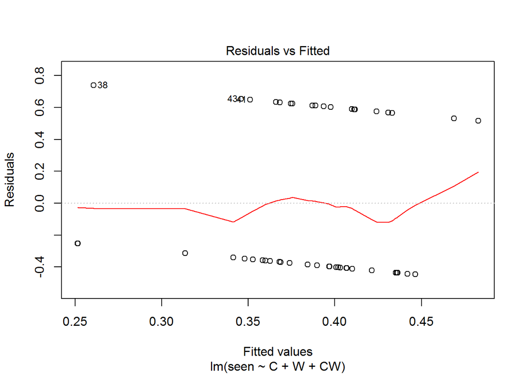

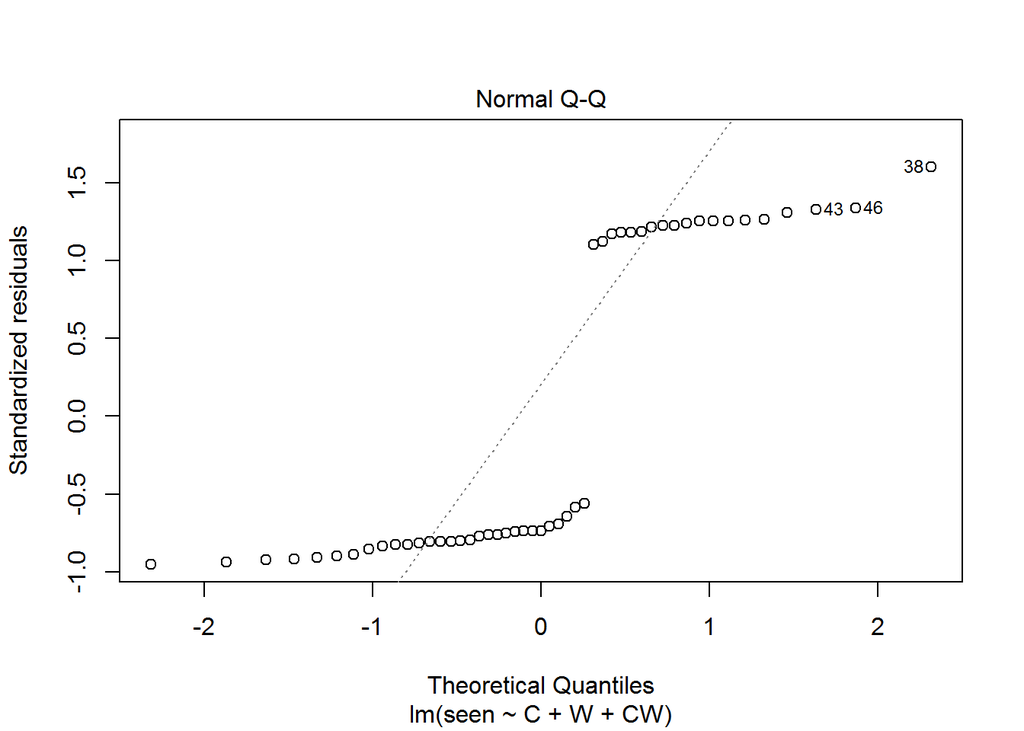

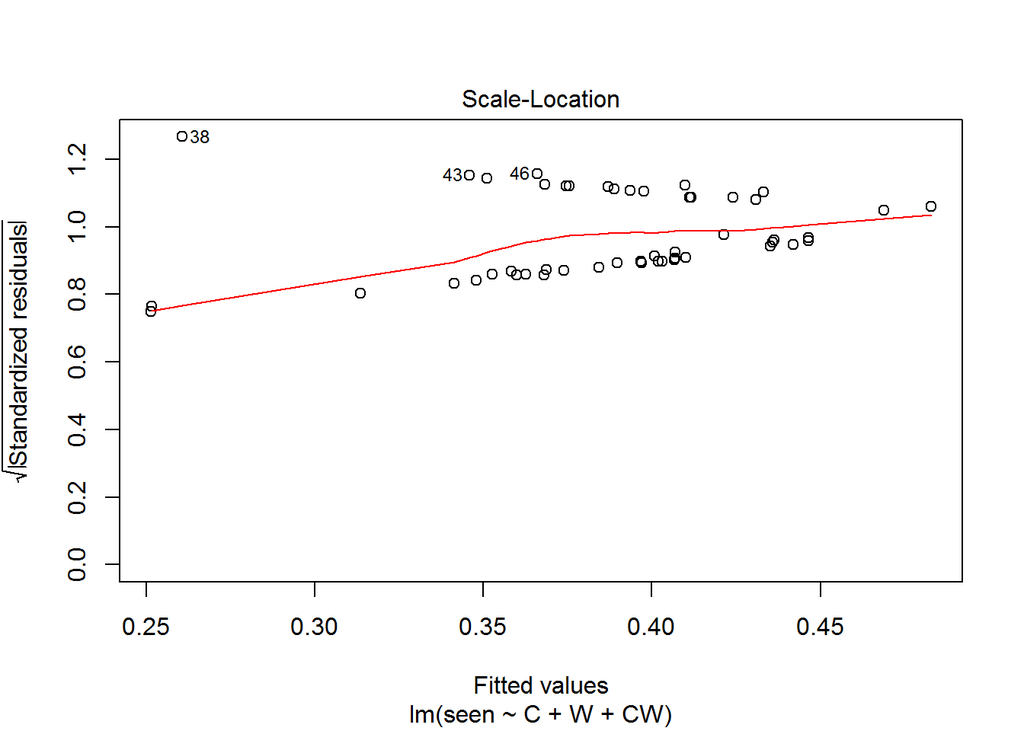

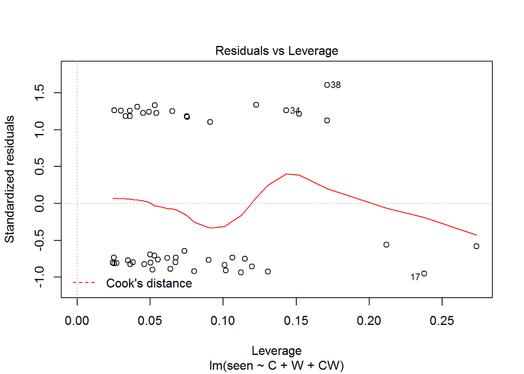

```r
plot(dat.lm)
```

```r
summary(dat.lm)
```

```
##
## Call:
## lm(formula = seen ~ C + W + CW, data = dat)
##
## Residuals:
##     Min      1Q  Median      3Q     Max
## -0.4465 -0.4020 -0.3526  0.5887  0.7392
##
## Coefficients:
##              Estimate Std. Error t value Pr(>|t|)
## (Intercept)  0.318073   0.482886   0.659    0.513
## C            0.001755   0.006858   0.256    0.799
## W           -0.002159   0.004313  -0.501    0.619
## CW           0.003280   0.010781   0.304    0.762
##
## Residual standard error: 0.5059 on 45 degrees of freedom
## Multiple R-squared:  0.009808,   Adjusted R-squared:  -0.0562
## F-statistic: 0.1486 on 3 and 45 DF,  p-value: 0.9301
```

4.Below, copy-paste the output from summary(dat.lm) and the plots from par(mfrow=c(1,2));plot(dat.lm,which=c(1:2)) . Write a brief conclusion about how much each predictor variable affects the response variable, whether or not that effect is significant, and what problems if any the plots reveal:

```r
glmfit<-glm(seen~C,data=gorilla,family=binomial())
```

```r
summary(glmfit)$coef
```

```
##                 Estimate Std. Error    z value  Pr(>|z|)
## (Intercept) -1.035173799 1.55354362 -0.6663307 0.5051997
## C            0.007757578 0.02041443  0.3800046 0.7039420
```

```r
cbind(summary(glmfit)$coef,exp(cbind(OR=coef(glmfit),confint(glmfit))))
```

```
##                 Estimate Std. Error    z value  Pr(>|z|)        OR
## (Intercept) -1.035173799 1.55354362 -0.6663307 0.5051997 0.3551646
## C            0.007757578 0.02041443  0.3800046 0.7039420 1.0077877
##                  2.5 %   97.5 %
## (Intercept) 0.01514682 7.473192
## C           0.96774891 1.050089
```

```r
glmfit2<-glm(seen~W,data=gorilla,family=binomial())
```

```r
cbind(summary(glmfit2)$coef,exp(cbind(OR=coef(glmfit2),confint(glmfit2))))
```

```
##                 Estimate Std. Error     z value Pr(>|z|)        OR
## (Intercept) -0.026721824 1.59210356 -0.01678397 0.986609 0.9736320
## W           -0.004315604 0.01573046 -0.27434695 0.783818 0.9956937
##                  2.5 %    97.5 %
## (Intercept) 0.04031007 23.629801
## W           0.96448103  1.027161
```

```r
glmfit3<-glm(seen~CW,data=gorilla,family=binomial())
```

```r
cbind(summary(glmfit3)$coef,exp(cbind(OR=coef(glmfit3),confint(glmfit3))))
```

```
##                Estimate Std. Error    z value  Pr(>|z|)        OR
## (Intercept) -1.15158427 1.60968346 -0.7154104 0.4743555 0.3161355
## CW           0.01469875 0.03339033  0.4402098 0.6597851 1.0148073
##                  2.5 %   97.5 %
## (Intercept) 0.01163376 7.198286
## CW          0.95041575 1.086012
```

Based on ORs, variables W,C,and WC do not predict the variable “seen”. ORs: for C=1.0, W=0.995, and for CW=1.014.